# Efecto de SCYLV en el rendimiento sacarino

Florencia Asinari

# Introduccion

Para evaluar el efecto de SCYLV en plantas de caña de azúcar se llevó a cabo un ensayo en dos zonas de producción diferentes: Ingenio Ledesma y EEA INTA-Famaillá. En cada lugar, se seleccionó un lote comercial de la variedad LCP 85-384, donde se marcaron 200 plantas distribuidas de la siguiente manera: 25 plantas por línea a un metro de distancia entre plantas y 8 líneas surco de por medio. De cada planta marcada, se tomó una muestra de hoja (+1) y se analizo mediante TBIA. Los resultados obtenidos mediante TBIA sirvieron para armar dos grupos de plantas: un grupo de positivas a SCYLV y un grupo de negativas a SCYLV. Con es información y cuando los lotes comerciales llegaron a la fase fenológica de maduración, ambos grupos se cosecharon por separado.Los parámetros de rendimiento sacarino medidos fueron: grados brix (ºBrix) y la lectura polarimétrica. A partir de dichos parámetros medidos en laboratorio, se calcularon los siguientes parámetros de rendimiento: Pol jugo,Pol caña, Pureza y el rendimiento fabril teórico.

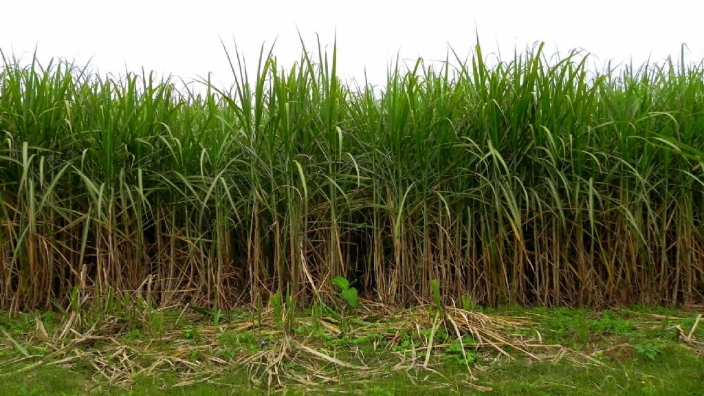

```r
setwd("C:/Users/Florencia/Dropbox/INTA/mis datos R")
```

```r
library(tidyverse)
rend <- readxl :: read_excel("C:/Users/Florencia/Dropbox/INTA/mis datos R/data/rend.xlsx")
```

## Exploracion estructura de datos

```r
str(rend)
```

```
## Classes 'tbl_df', 'tbl' and 'data.frame':    40 obs. of  10 variables:
##  $ Loc     : chr  "Famaillá" "Famaillá" "Famaillá" "Famaillá" ...
##  $ Sanid   : chr  "SCYLV+" "SCYLV+" "SCYLV+" "SCYLV+" ...
##  $ atdo    : num  1 2 3 4 5 6 7 8 9 10 ...
##  $ Peso    : num  3.6 3.6 3.4 3.2 3.8 2.8 2.8 3.6 3 3.4 ...
##  $ brix    : chr  "19.04" "19.12" "18.74" "18.9" ...
##  $ pol     : chr  "70.6" "72.2" "69.9" "72" ...
##  $ Pol_jugo: chr  "17.11" "17.49" "16.95" "17.45" ...
##  $ Pol_caña: chr  "13.86" "14.16" "13.73" "14.13" ...
##  $ Prza    : chr  "86.24" "87.8" "86.85" "88.65" ...
##  $ Rend    : chr  "10.52" "10.85" "10.46" "10.88" ...
```

```r
rend$Loc <- as.factor(rend$Loc)
rend$Sanid <- as.factor(rend$Sanid)
rend$brix <- as.numeric(rend$brix)
rend$pol <- as.numeric(rend$pol)
rend$Pol_jugo <- as.numeric(rend$Pol_jugo)
rend$Pol_caña <- as.numeric(rend$Pol_caña)
rend$Prza <- as.numeric(rend$Prza)
rend$Rend <- as.numeric(rend$Rend)
```

### Grafico de todas las observaciones (puntos)

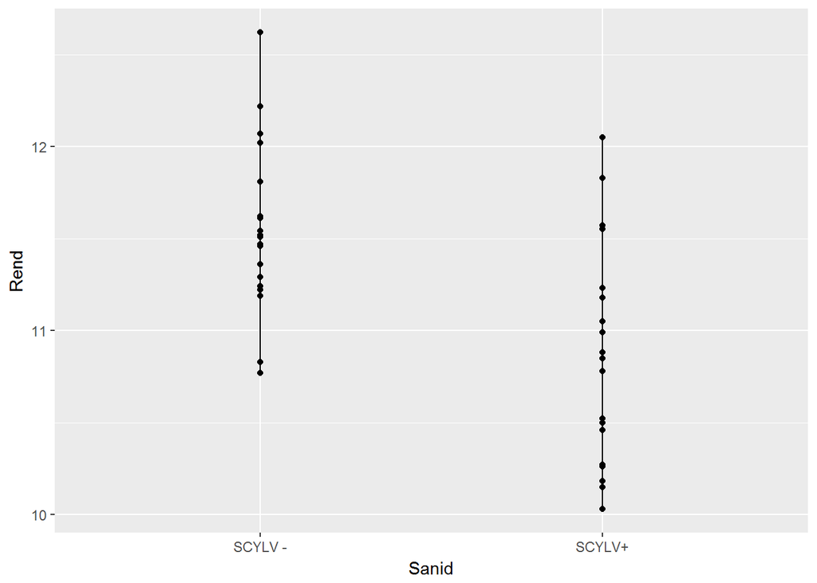

```r
ggplot(rend,aes(x=Sanid, y=Rend))+
  geom_point()+
  geom_line()
```

# ANOVA

```r
m1= lm(Rend ~ Loc * Sanid , data= rend)

anova(m1)
```

```
## Analysis of Variance Table
##
## Response: Rend
##           Df Sum Sq Mean Sq F value    Pr(>F)
## Loc        1 5.8504  5.8504 46.6816 5.452e-08 ***
## Sanid      1 4.2185  4.2185 33.6601 1.279e-06 ***
## Loc:Sanid  1 0.2731  0.2731  2.1792    0.1486
## Residuals 36 4.5117  0.1253
## ---
## Signif. codes:  0 '***' 0.001 '**' 0.01 '*' 0.05 '.' 0.1 ' ' 1
```

```r
summary(m1)
```

```
##
## Call:
## lm(formula = Rend ~ Loc * Sanid, data = rend)
##
## Residuals:
##      Min       1Q   Median       3Q      Max
## -0.55857 -0.30250  0.00038  0.27093  0.70143
##
## Coefficients:
##                        Estimate Std. Error t value Pr(>|t|)
## (Intercept)            11.29000    0.09819 114.986  < 2e-16 ***
## LocLedesma              0.62857    0.16596   3.787 0.000558 ***
## SanidSCYLV+            -0.77077    0.13886  -5.551 2.77e-06 ***
## LocLedesma:SanidSCYLV+  0.34648    0.23471   1.476 0.148578
## ---
## Signif. codes:  0 '***' 0.001 '**' 0.01 '*' 0.05 '.' 0.1 ' ' 1
##
## Residual standard error: 0.354 on 36 degrees of freedom
## Multiple R-squared:  0.6963, Adjusted R-squared:  0.6709
## F-statistic: 27.51 on 3 and 36 DF,  p-value: 1.997e-09
```

##Comparacion de supuestos

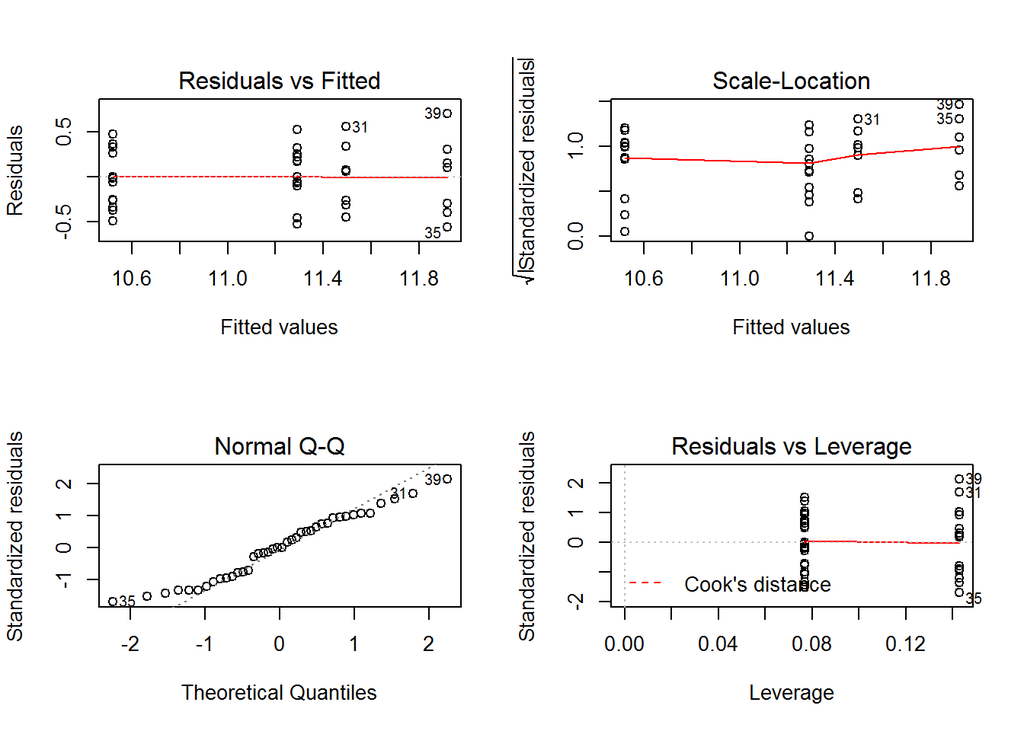

```r
#x11()
layout(matrix(1:4,2,2))
plot(m1)
```

```r
layout(1)
```

```r
shapiro.test(residuals(m1))
```

```
##
##  Shapiro-Wilk normality test
##
## data:  residuals(m1)
## W = 0.962, p-value = 0.196
```

```r
bartlett.test(resid(m1)~rend$Loc)
```

```
##
##  Bartlett test of homogeneity of variances
##
## data:  resid(m1) by rend$Loc
## Bartlett's K-squared = 0.69328, df = 1, p-value = 0.4051
```

```r
bartlett.test(resid(m1)~rend$Sanid)
```

```
##
##  Bartlett test of homogeneity of variances
##
## data:  resid(m1) by rend$Sanid
## Bartlett's K-squared = 0.1133, df = 1, p-value = 0.7364
```

## Test de comparacion de medias (Tukey)

```r
library(emmeans)
em <- emmeans(m1, ~ Loc|Sanid)
result_m1 <- cld(em,
                 Letters = "abcdef",
                 reverse = FALSE)
```

```r
library(emmeans)
em <- emmeans(m1, ~ Sanid|Loc)
result_m1 <- cld(em,
                 Letters = "abcdef",
                 reverse = FALSE)
```

# Grafico final

```r
class(result_m1)
```

```
## [1] "summary_emm" "data.frame"
```

```r
result_m1$.group
```

```
## [1] " a " "  b" " a " "  b"
```

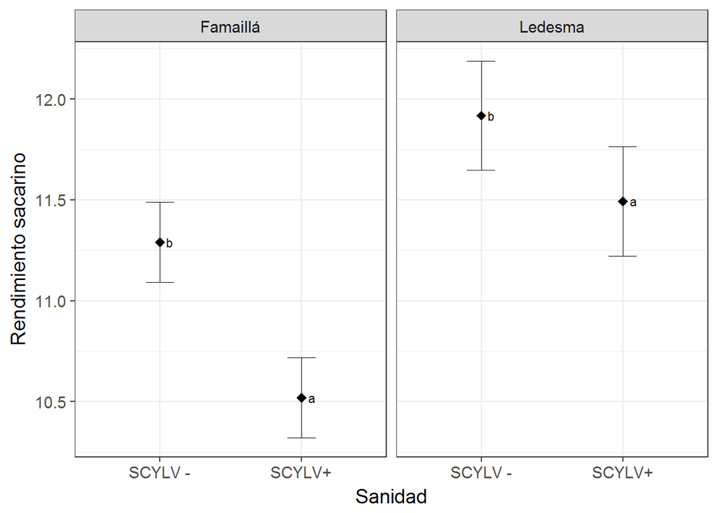

```r
result_m1$let <-  c ("a","b","a","b")

ggplot(result_m1,
         aes(x = Sanid, y=emmean))+
           geom_point(shape=18, size=3)+
           geom_errorbar(aes(ymin=lower.CL, ymax=upper.CL), width=.2, size=0.3)+
           geom_text(aes(label=let, x=Sanid, y=emmean, hjust = -1), size=3)+
           labs(x="Sanidad",
                y="Rendimiento sacarino") +
           theme_bw(base_size=14)+
  facet_wrap(~Loc)
```

```r
ggsave("C:/Users/Florencia/Dropbox/INTA/mis datos R/plots/plot_final.tiff", w=8,h=8, units="cm", scale=2, dpi=300)
```

# Conclusion

Hay diferencias significativas entre el rendimiento de plantas sanas y enfermas, tanto en Famailla como en Ledesma